# Gamma Spectroscopy

### Step 3: Determine the relative ratio between the two strongest peaks by fitting and integrating the peaks.

The ratio $S$ between the two peak intensities is calulated using the following equation: $$S=\frac{I_{511}}{I_{1275}} $$ Remember to take into account the detectors efficency ($\epsilon$) at the two different energies: $$S=\frac{I_{511}}{I_{1275}}\cdot \frac{1/\epsilon_{511}}{1/\epsilon_{1275}} \Rightarrow S = \frac{\frac{I_{511}}{\epsilon_{511}}}{\frac{I_{1275}}{\epsilon_{1275}}}$$

In order to aclculate the intensity of each peak, they need to be fitted (with Gaussian) and then integrated to obtain the area.

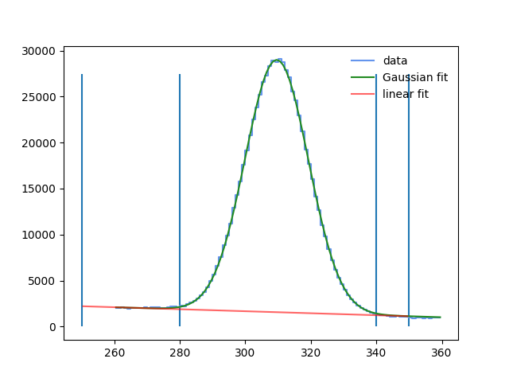

```
Estimated parameters:
 A = 27423.26893, mu = 309.61018,  sigma = 9.66196

Uncertainties in the estimated parameters:
 σ²(A) = 1362.58475, σ²(mu) = 0.00023, σ²(sigma) = 0.00023

Covariance matrix:
 [[ 1.36258475e+03  1.53322129e-07 -3.20050070e-01]
 [ 1.53322129e-07  2.25524429e-04 -5.41434403e-11]
 [-3.20050070e-01 -5.41434403e-11  2.25524428e-04]]

 Area (intensity) of the 511 keV peak: 664162.2959221537
```

```python
# For Na-22 511 keV peak:

# Like before the fitting software needs an intial guess of the parameters of the gaussian:

Na22_peak1 = fittingFunctions.perform_Gaussian_fit(x=Na22.bin_centers, # your x data
                                              y=Na22.counts,           # your y data
                                              region_start=260,   # -> TODO <- Insert channel number from where to START fitting.
                                              region_stop=360,    # -> TODO <- Insert channel number from where to STOP fitting.
                                              mu_guess=306,       # -> TODO <- Insert intial guess of peak centroid (mean value of the peak)
                                              A_guess=30000,      # -> TODO <- Insert intial guess for the constant 'A' (amplitude of the peak)
                                              sigma_guess=10,
                                              left_selection = [250 ,280 ],  # -> TODO <- Insert channel numbers (a region) to the LEFT of the peak where to START fitting the linear background for subtraction
                                              right_selection = [ 340, 350])     # -> TODO <- Insert intial guess for the standard diviation (width of the peak)

print("\n Area (intensity) of the 511 keV peak: {}".format(Na22_peak1.area()))

#After executing this cell (Shift + Enter) the fitted parameters and the area of the peak can be seen below the plot.
```

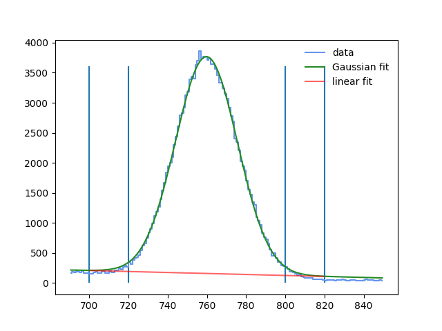

```
Estimated parameters:
 A = 3609.18201, mu = 759.78460,  sigma = 15.84624

Uncertainties in the estimated parameters:
 σ²(A) = 119.16931, σ²(mu) = 0.00306, σ²(sigma) = 0.00306

Covariance matrix:
 [[ 1.19169306e+02  2.62537429e-07 -3.48812919e-01]
 [ 2.62537429e-07  3.06296368e-03 -1.21743500e-09]
 [-3.48812919e-01 -1.21743500e-09  3.06296423e-03]]

 Area (intensity) of the 1275 keV peak: 143359.0304397162
```

```python
# For Na-22 1275 keV peak:

# Like before the fitting software needs an intial guess of the parameters of the gaussian:

Na22_peak2 = fittingFunctions.perform_Gaussian_fit(x=Na22.bin_centers, # your x data
                                              y=Na22.counts,           # your y data
                                              region_start=690,   # -> TODO <- Insert channel number from where to START fitting.
                                              region_stop=850,    # -> TODO <- Insert channel number from where to STOP fitting.
                                              mu_guess=750,       # -> TODO <- Insert intial guess of peak centroid (mean value of the peak)
                                              A_guess=5000,      # -> TODO <- Insert intial guess for the constant 'A' (amplitude of the peak)
                                              sigma_guess=15,
                                              left_selection = [700 ,720 ],  # -> TODO <- Insert channel numbers (a region) to the LEFT of the peak where to START fitting the linear background for subtraction
                                              right_selection = [ 800,820 ])     # -> TODO <- Insert intial guess for the standard diviation (width of the peak)

print("\n Area (intensity) of the 1275 keV peak: {}".format(Na22_peak2.area()))

#After executing this cell (Shift + Enter) the fitted parameters and the area of the peak can be seen below the plot.
```

```python
#Finally, put in the efficency values for each energy and execute to calculate the relative ratio 'S'.
peak1_eff = 0.72# -> TODO <- Insert the detector efficiency at 511 keV.
peak2_eff = 0.35# -> TODO <- Insert the detector efficiency at 1275 keV.

#### NO NEED TO EDIT ####
Ratio = (Na22_peak1.area()/peak1_eff)/(Na22_peak2.area()/peak2_eff)

print('Intensity (511 keV) = {}'.format(Na22_peak1.area()))
print('Intensity (1275 keV) = {}'.format(Na22_peak2.area()))
print('Detector eff. (511 keV) = {}'.format(peak1_eff))
print('Detector eff. (1275 keV) = {}'.format(peak2_eff))
print('>> Relative ratio: S = {} <<'.format(round(Ratio,5)))
#########################
```

```
Intensity (511 keV) = 664162.2959221537
Intensity (1275 keV) = 143359.0304397162
Detector eff. (511 keV) = 0.72
Detector eff. (1275 keV) = 0.35
>> Relative ratio: S = 2.25208 <<
```

### Task 4 Questions:

(double click to edit, Shift + Enter to execute changes)

**Question 1**: Based on the decay schema of Na-22, what relative intensity do you expect and why?

**->** I would expect a relative eintensity of 1.8, because there is a 0.9 chance of b+ decay, and for every gamma decause there is annhilation, releasing two fotons. Two * 0.9 = 1.8, which is why it is the excpected relative intensity.

**Question 2**: Why is you final result slighly off this estimation?

**->** One reason for this is that our measurement is short, if we had a longer measurement we would recive a more accurate measurement.

## Task 5: Cs-137 and the internal conversion coefficient of Ba-137

Remeber, the internal conversion coefficient is given by the ratio between number of internal conversion ($N_{IC}$) and the number of $\gamma$-emissions ($N_{\gamma}$): $$\alpha = \frac{N_{IC}}{N_{\gamma}}$$ Since out NaI detector can only detect photons, what we are actully comparing is the ratio between the emission of characteristic x-ray emission which occures as a **result** of internal conversion with the emission of gamma-rays from Ba-137.

$$\alpha = \frac{N_{x-ray}}{N_{\gamma}}$$

We then have to take into account the detector efficiency for the different photon energies: $E_{x-ray} = 32$ keV and $E_{\gamma} = 662$ keV: $$\alpha = \frac{N_{32}}{N_{662}} \cdot \frac{1/\epsilon_{32}}{1/\epsilon_{662}} \Rightarrow \alpha = \frac{\frac{I_{32}}{\epsilon_{32}}}{\frac{I_{661}}{\epsilon_{662}}}$$ In the case of $^{137}$Ba there is also a 10% possibility of getting an emssion of an Auger electron and, therefore, one x-ray less! We need to account for this in our measurement: $$\alpha = \frac{\frac{I_{32}}{\epsilon_{32}}}{\frac{I_{661}}{\epsilon_{662}}\cdot 0.9}$$

### Step 2: Import and plot the data

```python
#Load your data file here:
Cs137_gain = MCA.load_spectrum("CS-137.2.Spe") #-> TODO <- Insert the name of your data file. Source: Cs-137 with higher gain.

#Cs137_gain.calibrate(k,m) #Calibrate the sample?
```

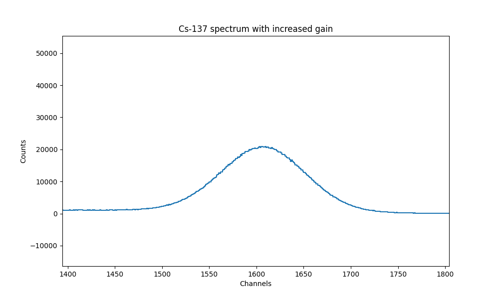

```python
#Execute to make plot of Na-22 spectrum

#### NO NEED TO EDIT ####
plt.figure(figsize=(10, 6))
# with the data read in with the first routine
plt.step(Cs137_gain.bin_centers, Cs137_gain.counts, where='mid', label='step')
plt.title("Cs-137 spectrum with increased gain") # set title of the plot
plt.xlabel("Channels")     # set label for x-axis
plt.ylabel("Counts")       # set label for y-axis
#plt.savefig("th232_spectrum.png") #This is how you save the figure
#########################
```